# **Chapter 5: CPU Scheduling - Introduction**

#### **Generating Input for the Simulation (The "Driver")**

The biggest question is: what data should be used to test the system? There are two primary methods, each with trade-offs.

**1. Distribution-Driven Simulation (Synthetic Input)**

- **How it works:** A **random-number generator** is used to create artificial events (process arrivals, CPU burst lengths, etc.). These events are generated according to a specified **probability distribution** (e.g., exponential, uniform).
- **Types of Distributions:**
  - **Mathematical:** Using a standard statistical distribution.
  - **Empirical:** Using a distribution measured from a real system.
- **Disadvantage:** This method may be inaccurate because it only captures the *frequency* of events, not the *order* or *relationships* between them. Real systems often have sequences of events that are correlated, which a random distribution might not replicate.

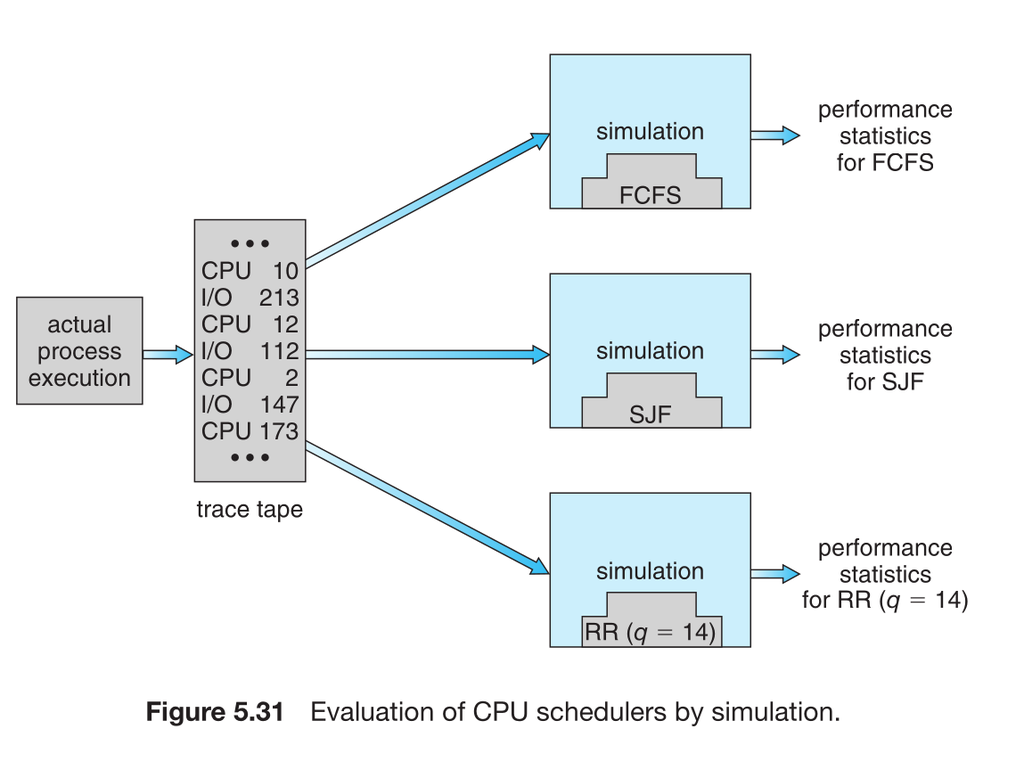

**2. Trace Tape Simulation (Real Input)**

- **How it works:** This method uses a recorded log, or **trace file**, of the actual events that occurred on a real system.
- **Go to Figure 5.31:** This figure illustrates the process perfectly.
  1. A real system is monitored, and a detailed log (the "trace tape") is created, recording the exact sequence of process executions, CPU bursts, and I/O operations.
  2. This trace file is then used as the input to drive the simulator for different algorithms (FCFS, SJF, RR).
- **Major Advantage:** This is the **best method for comparing algorithms** because it tests them all on the *exact same set of real inputs*. This allows for a direct, fair, and highly accurate comparison of their performance on a realistic workload.

#### **Disadvantages of Simulations**

Despite being highly useful, simulations have significant costs:

1. **Computational Expense:** Simulations can require **hours of computer time**, especially detailed ones.
2. **Detail vs. Cost Trade-off:** A more detailed and accurate simulation model takes significantly more time to run.
3. **Storage Space:** Trace files that record extensive system activity can consume **large amounts of storage space**.
4. **Development Effort:** The **design, coding, and debugging** of the simulator itself is a complex and time-consuming software engineering task.

### **5.8.4 Implementation**

#### **The Most Accurate and Costly Method**

The only way to know *exactly* how a scheduling algorithm will perform for a specific environment is to **code it, install it in the real operating system kernel, and let users run their real applications on it.**

- This is not a model or an approximation; it is the **actual system** under test.
- The major advantage is that you get to see the scheduler's performance under a **completely realistic workload**, including all the complex, unpredictable interactions of real user behavior and applications.

#### **The Major Drawback: High Cost and Risk**

While implementation provides the most valid results, it is also the most difficult and dangerous approach for several reasons:

1. **Expense and Disruption:**
   - Implementing a new scheduler requires **modifying the operating system kernel**, which is a complex and sensitive task.
   - Once implemented, the scheduler affects **every process and user** on the system.
   - Putting an experimental, and potentially poorly performing, algorithm into a production system can lead to **severe performance degradation** and user dissatisfaction.
2. **The Environment is Never Constant:**
   - The "best" algorithm under one workload might be the worst under another.
   - Users' needs and the mix of applications change over time. An algorithm tuned for today's workload might be a poor fit for tomorrow's.
   - This makes it difficult to draw permanent, general conclusions from a single implementation.

Because of these high costs and risks, new scheduling algorithms are typically thoroughly evaluated using **simulations** and **analytic models** before they are ever considered for a real implementation in a production operating system.

## **5.9 Summary**

#### **Core Concepts**

- **CPU Scheduling** is the process of selecting a waiting process from the **ready queue** and allocating the CPU to it. The **dispatcher** is the module that handles the actual context switch.
- Algorithms are either **preemptive** (the OS can force a process off the CPU) or **nonpreemptive** (the process keeps the CPU until it releases it). Modern OSes are predominantly preemptive.
- The five key **evaluation criteria** are: CPU Utilization, Throughput, Turnaround Time, Waiting Time, and Response Time.

#### **Fundamental Scheduling Algorithms**

- **First-Come, First-Served (FCFS):** Simple, but can lead to the **convoy effect**, where short processes wait for one long process.
- **Shortest-Job-First (SJF):** **Provably optimal** for minimizing average waiting time. The challenge is **accurately predicting** the length of the next CPU burst. It can be nonpreemptive or preemptive (Shortest-Remaining-Time-First).
- **Round-Robin (RR):** Designed for time-sharing. Each process runs for a **time quantum**. It is preemptive and provides good response time. Performance depends heavily on the size of the quantum.
- **Priority Scheduling:** Schedules processes based on **priority**. Can lead to **indefinite blocking (starvation)** of low-priority processes, which is often solved by **aging** (gradually increasing a process's priority over time).
- **Multilevel Queue:** Partitions the ready queue into several separate queues (e.g., system, interactive, batch), each with its own scheduling algorithm and priority level.
- **Multilevel Feedback Queue:** Similar to multilevel queues, but allows processes to **migrate between queues** based on their observed behavior (e.g., a CPU-bound process may be moved to a lower-priority queue).

#### **Multiprocessor and Real-Time Scheduling**

- **Multicore Systems:** Present logical CPUs to the OS. Scheduling must consider:
  - **Load Balancing:** Distributing work evenly across cores. This can be done via **push migration** (a master thread moves tasks) or **pull migration** (an idle core pulls a task).
  - **Processor Affinity:** Trying to keep a thread on the same processor to benefit from a **warm cache**. This can be **soft** (best effort) or **hard** (mandatory).
  - **NUMA:** On Non-Uniform Memory Access systems, scheduling a thread on a CPU close to its memory is critical for performance.
- **Heterogeneous Multiprocessing (HMP):** Uses cores with different performance and power characteristics (e.g., ARM's big.LITTLE) to optimize for power efficiency.
- **Real-Time Scheduling:**
  - **Soft Real-Time:** No guarantees, but gives preference to real-time tasks.
  - **Hard Real-Time:** Requires absolute deadline guarantees.
  - **Rate-Monotonic Scheduling (RMS):** A **static-priority** algorithm for periodic tasks where a **shorter period means a higher priority**. It is optimal among static-priority schedulers but has a CPU utilization bound of `N(2^(1/N) - 1)`.
  - **Earliest-Deadline-First (EDF):** A **dynamic-priority** algorithm where the **earliest deadline has the highest priority**. It is theoretically optimal and can achieve 100% CPU utilization.
  - **Proportional Share:** Allocates T shares among applications; a task with N shares is guaranteed N/T of the CPU time. Requires **admission control**.

#### **Operating System Examples**

- **Linux (Completely Fair Scheduler - CFS):** Aims for "fair" CPU distribution. It uses **virtual run time (vruntime)** to track how much CPU a task has effectively used, always scheduling the task with the smallest `vruntime`. It uses a **red-black tree** for efficiency and is **NUMA-aware**.
- **Windows:** Uses a **preemptive, priority-based** algorithm with **32 priority levels** (1-15 variable class, 16-31 real-time class). It dynamically adjusts priorities: **lowers** them for CPU-bound threads and **boosts** them for I/O-bound and interactive threads. The **foreground process** gets a longer time quantum.
- **Solaris:** Uses six **scheduling classes** (Time Sharing, Interactive, Real Time, System, Fair Share, Fixed Priority). The Time-Sharing class uses a **multilevel feedback queue** with an **inverse relationship between priority and time quantum**. All class-specific priorities are mapped to a single **global priority** for the final scheduling decision.

#### **Algorithm Evaluation Methods**

- **Deterministic Modeling:** Uses a **predetermined, specific workload** for exact analysis. Simple and good for examples, but not generalizable.
- **Queueing Models:** Uses **probability distributions** for arrivals and burst times to analyze system performance mathematically. **Little's Formula (n = λ × W)** is a key, universal result.
- **Simulations:** Involves **programming a model** of the system. Can be driven by **random distributions** or, more accurately, by a **trace tape** of a real system's events. More accurate but computationally expensive.
- **Implementation:** Coding the algorithm into a real OS kernel. Provides the most valid results but is the most costly, disruptive, and risky approach.